# PP03_final

## Autores

Carlos Augusto Jardim Chiarelli **165685**

Marco Antonio D'Angelo **173656**

$$$$

# ES672 – Sistemas Fluidotérmicos I – turma A

$$$$

# **Problema Proposto 03**

$$$$

```python
# bibliotecas
import numpy             as np
import matplotlib.pyplot as plt
from   pandas            import DataFrame, read_excel, concat
from   platform          import python_version
from   warnings          import filterwarnings
from   IPython.display   import Image
from   copy              import deepcopy
from   pylab             import rcParams

rcParams['figure.figsize'] = 13, 6

filterwarnings('ignore')

def mostra(var, nome, unidade, arred=1, mul=None):

    if mul: var = {k:v*mul for k, v in var.items()}

    df = DataFrame(var, index=[0])
    df = df.round(arred)
    df[nome] = unidade

    return df

class Gas_ideal:
    ''' Calcula propriedades termodinâmicas do GÁS IDEAL (tabela A22) '''

    def __init__(self):
        ''' Inicializa os parâmetros '''

        self.a22_df  = read_excel('tabelaA22_gasIdeal.xlsx') # propriedades Gás Ideal
        self.prop_df = None

        self.param  = {'nome':None,'valor':None} # variável para interpolar

    def existe_temp(self):
        '''
        Diz se a temperatura existe na tabela
        :return: Boolean indica se a temperatura existe
        '''
        lgc = self.a22_df[self.param['nome']] == self.param['valor']

        if lgc.any():
            index        = np.where(lgc)[0][0]
            self.prop_df = self.a22_df.loc[index,:]
            return True
        else:
            return False

    def interpolacao(self):
        '''
        Faz interpolação das propriedades de acordo com parâmetro
        :return: Integer é o index se exister
        '''
        lgc   = self.a22_df[self.param['nome']] < self.param['valor']
        index = np.where(lgc)[0][-1] # último elemento

        l1, l2 = index, index+2
        self.prop_df = self.a22_df.loc[l1:l2,:].copy()

        aux = {self.param['nome'] : self.param['valor']}

        x    = self.prop_df.loc[:,self.param['nome']].tolist()
        cols = self.prop_df.columns.tolist()
        cols.remove(self.param['nome'])

        for col in cols:
            y        = self.prop_df.loc[:,col].tolist()
            aux[col] = np.interp(self.param['valor'], x, y)

        self.prop_df = aux

    def get_propTerm(self, **kwargs):
        ''' Obtém as propriedades térmica
        **kwargs -> o nome do parâmetro deve ser igual ao nome da coluna
                 -> ['T', 'h', 'u', 's', 'pr', 'vr']
                 -> unidades de acordo com a tabela 22
        :return: Dictionary com valores interpolados
        '''

        for key, value in kwargs.items():
            self.param['nome'], self.param['valor'] = key, value
            break

        if not self.existe_temp(): self.interpolacao()

        return self.prop_df

def get_vet_var(valor, key, minim=.95, maxim=1.05, num=10):
    ''' Cria um vetor variando entre -+5% espaçados em 10 partes '''
    if key != 'rend_eletMec':
        return np.linspace(valor*minim, valor*maxim, num)
    else:
        return np.linspace(valor*minim, .99, num)

def get_vet_var_10(valor, key, minim=.90, maxim=1.1, num=10):
    ''' Cria um vetor variando entre -+10% espaçados em 10 partes '''
    if key != 'efic_dif_boc':
        return np.linspace(valor*minim, valor*maxim, num)
    else:
        return np.linspace(valor*minim, 1, num)

def avalia_sensibilidades_corr(sistema='A'):
    ''' Obtém a correlação entre parâmetros de entrada e resultados  '''
    var_todas = []
    primeiro  = True
    correl    = {}

    var_params_aux = {k:get_vet_var(v,k, num=100) for k,v in params.items()}
    if 'efic_dif_boc' in list(var_params_aux.keys()): del var_params_aux['efic_dif_boc']

    # simulação para cada um dos novos parâmetros
    for key, valores in var_params_aux.items():

        novos_params  = []

        for valor in valores:

            if sistema == 'A':
                sistema_var = deepcopy(sistema_A)
            elif sistema == 'B':
                sistema_var = deepcopy(sistema_B)

            if key=='perdaCarg_comb': sistema_var.perdaCarg_comb = valor
            if key=='tempMax_ciclo':  sistema_var.tempMax_ciclo  = valor
            if key=='efic_comp':      sistema_var.efic_comp      = valor
            if key=='efic_exp':       sistema_var.efic_exp       = valor
            if key=='rend_eletMec':   sistema_var.rend_eletMec   = valor
            if key=='perda_carga':    sistema_var.perda_carga    = valor
            if key=='T_max_opr':      sistema_var.T_max_opr      = valor
            if key=='efic_iso_comp':  sistema_var.efic_iso_comp  = valor
            if key=='efic_iso_exp':   sistema_var.efic_iso_exp   = valor

            sistema_var.simulacao()

            novos_params.append(sistema_var.get_params())

        if primeiro:
            if sistema == 'A':
                var_todas = DataFrame(novos_params, columns=['pot_liq','efic_sist','T4_celsius'])
            elif sistema == 'B':
                var_todas = DataFrame(novos_params, columns=['F_empuxo','m_comb','empuxo_especifico'])
            primeiro  = False
            var_todas['nome']  = key
            var_todas['valor'] = valores
            correl[key] = var_todas.corr()['valor']

        else:
            if sistema == 'A':
                aux = DataFrame(novos_params, columns=['pot_liq','efic_sist','T4_celsius'])
            elif sistema == 'B':
                aux = DataFrame(novos_params, columns=['F_empuxo','m_comb','empuxo_especifico'])
            aux['nome']  = key
            aux['valor'] = valores
            correl[key]  = aux.corr()['valor']
            var_todas = var_todas.append(aux)

    if sistema == 'A':
        return DataFrame(correl).loc['pot_liq':'T4_celsius',:].round(4)
    elif sistema == 'B':
        return DataFrame(correl).loc['F_empuxo':'empuxo_especifico',:].round(4)
    else:
        return

def mostra_mex_ISO():
    df_Mex = DataFrame({'Parâmetro'        : ['Empuxo em condições de cruzeiro', 'Consumo de combustível',
                                            'Empuxo específico em cruzeiro', 'Desvio empuxo em condições de cruzeiro',
                                            'Desvio de consumo de combustível', 'Desvio empuxo específico em cruzeiro'],
                      'Cruzeiro'         : [parametros_otim[0].round(2),
                                            parametros_otim[1].round(2),
                                            parametros_otim[2].round(2),
                                            desvios_otim[0].round(2),
                                            desvios_otim[1].round(2),
                                            desvios_otim[2].round(2)],
                      'ISO'              : [params_ISO[0].round(2),
                                            params_ISO[1].round(2),
                                            params_ISO[2].round(2),
                                            desvios_ISO[0].round(2),
                                            desvios_ISO[1].round(2),
                                            desvios_ISO[2].round(2)],
                      'Cidade do México' : [params_Mexico[0].round(2),
                                            params_Mexico[1].round(2),
                                            params_Mexico[2].round(2),
                                            desvios_Mexico[0].round(2),
                                            desvios_Mexico[1].round(2),
                                            desvios_Mexico[2].round(2)],
                      'Unidade'          : ['N', 'g/s','(g/s)/kN','%','%','%']})

    return df_Mex

print('\n\nVersão da Linguagem Python usada neste relatório:', python_version(), '\n\n')
```

```
Versão da Linguagem Python usada neste relatório: 3.7.7
```

$$$$

# **Enunciado**

$$$$

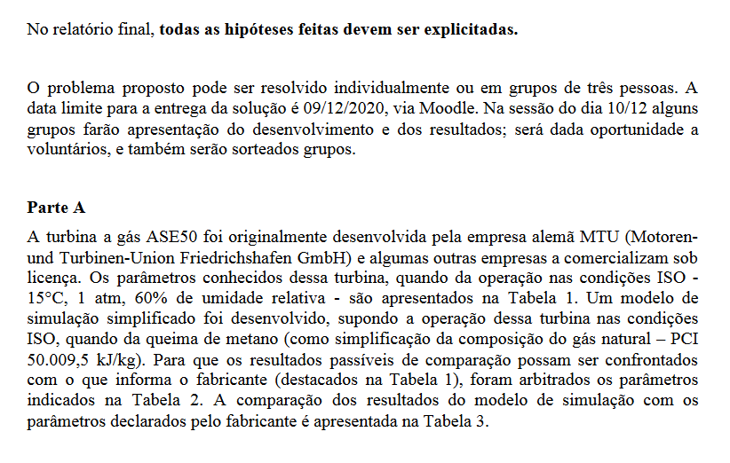

```python
Image('../dados/imagens/pp3_01.PNG')
```

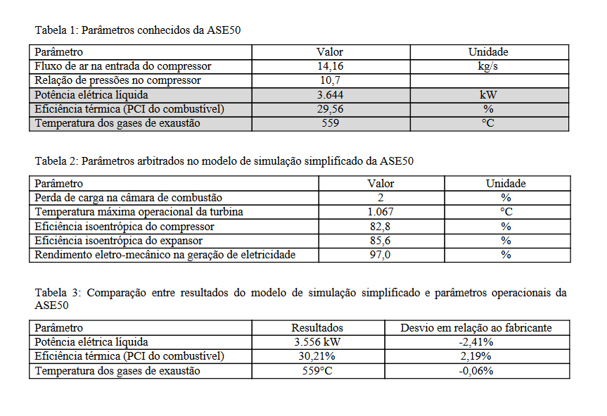

```python
Image('../dados/imagens/pp3_02.PNG')
```

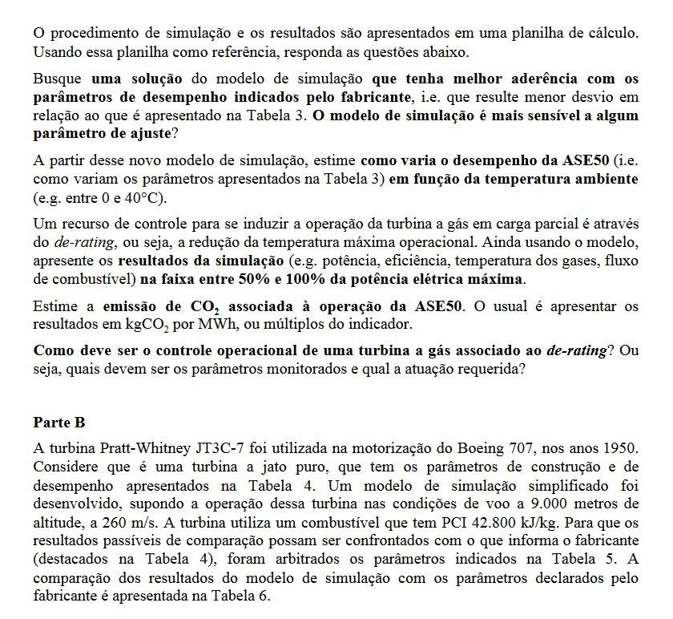

```python
Image('../dados/imagens/pp3_03.PNG')
```

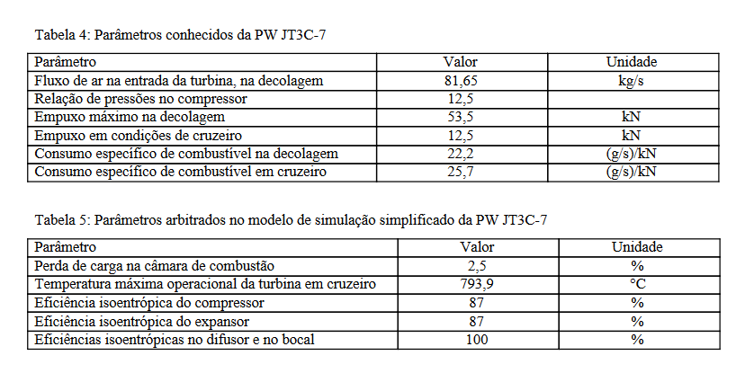

```python
Image('../dados/imagens/pp3_04.PNG')
```

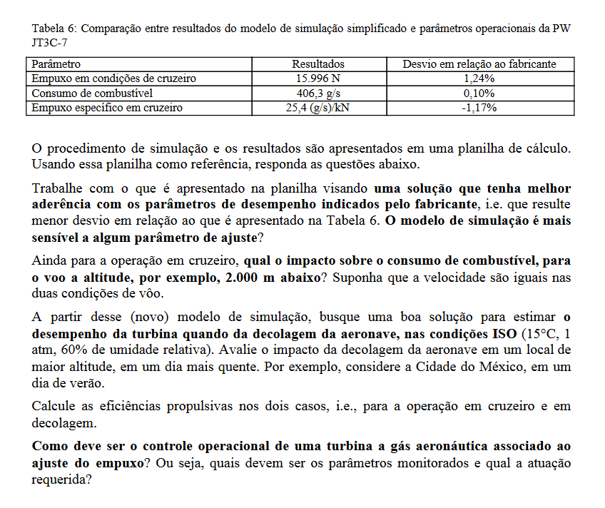

```python
Image('../dados/imagens/pp3_05.PNG')
```

$$$$

# **Parte A**

$$$$

Abaixo vemos o modelo do problema proposto: $$$$

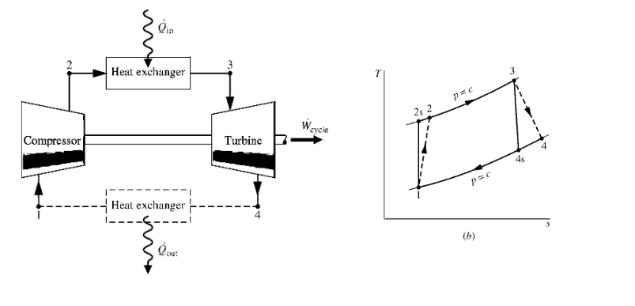

```python
Image('../dados/imagens/pp3_06.PNG')
```

$$$$

```python
# o prefixo "a." pode ser ignorado, é apenas uma peculiaridade da linguagem que permite
# todas as funções (da mesma classe) enxergarem a variável com esse prefixo

class Turbina():
    ''' Essa classe caracteriza o sistema TURBINA onde o fluído é um Gás ideal'''

    def __init__(a, m_ponto, p_rel_comp, perdaCarg_comb, pci_gas, tempMax_ciclo, efic_comp, efic_exp, rend_eletMec, temp_comp, p_comp, p_turb, paramFab):
        ''' Inicializa os parâmetros '''

        a.m_ponto        = m_ponto        # Fluxo de ar no compressor
        a.p_rel_comp     = p_rel_comp     # relação de pressões na compressão
        a.perdaCarg_comb = perdaCarg_comb # perda carga do ar na câm. combustão
        a.pci_gas        = pci_gas        # PCI do gás natural
        a.tempMax_ciclo  = tempMax_ciclo  # temperatura máxima do ciclo
        a.efic_comp      = efic_comp      # eficiência isentrópica do compressor
        a.efic_exp       = efic_exp       # eficiência isentrópica na expansão
        a.rend_eletMec   = rend_eletMec   # rendimento eletro-mecânico
        a.temp_comp      = temp_comp      # temperatura Compressor
        a.p_comp         = p_comp         # pressão compressor
        a.p_turb         = p_turb         # pressão turbina
        a.paramFab       = paramFab       # parâmetros do fabricante

        a.ar = Gas_ideal()    # fluido

        a.temp_K = 273.15  # °C  -> K
        a.p_kPa  = 101.325 # atm -> kPa

    def compressor_ar(a):
        ''' Análise do  compressor de ar
            ESTADO 1 -> compressor de ar -> ESTADO 2
        '''

        # ENTRADA COMPRESSOR (estado 1)
        a.T1 = a.temp_comp + a.temp_K        # temp de entrada de ar
        a.p1 = a.p_comp    * a.p_kPa         # pressao de entrada de ar

        a.prop1 = a.ar.get_propTerm(T = a.T1)  # propriedades estado 1

        # SAÍDA COMPRESSOR (estado 2)
        a.p2       = a.p_rel_comp * a.p_comp       # pressao
        a.pr2      = a.p_rel_comp * a.prop1['pr']  # pr

        a.p2_kPa   = a.p2 * a.p_kPa

        a.prop2    = a.ar.get_propTerm(pr = a.pr2)  # propriedades estado 2 (isoentrópico)

        a.T2_graus = a.prop2['T'] - a.temp_K

        # Entalpia (REAL - efic. isoentrópica)
        a.h2 = ((a.prop2['h'] - a.prop1['h']) / a.efic_comp) + a.prop1['h']

        a.prop2_real = a.ar.get_propTerm(h = a.h2)  # propriedades estado 2 (REAL)

        # provando que chegamos em resultados iguais

        # Potência do compressor (mg*(h2s-h1))/eff
        a.pot_comp  = (a.m_ponto * (a.prop2['h'] - a.prop1['h'])) / a.efic_comp

        # Potência do compressor (mg*(h2-h1))
        a.pot_comp2 = a.m_ponto * (a.h2 - a.prop1['h'])

    def camara_combustao(a):
        ''' Análise da  câmara de combustão
            ESTADO 2 -> câmara de combustão -> ESTADO 3
        '''

        a.temp_comb  = a.tempMax_ciclo + a.temp_K          #  temp

        a.p3     = (1 - (a.perdaCarg_comb/100)) * a.p2 #  pressao
        a.p3_kPa = a.p3 * a.p_kPa

        a.prop3  = a.ar.get_propTerm(T = a.temp_comb)  # propriedades estado 3

        # !!! NÃO ENTENDI O PQ DESSA FÓRMULA !!!

        num = a.m_ponto * (a.prop3['h'] - a.h2)
        den = a.pci_gas - (a.prop3['h'] - a.h2)

        a.m_ponto_comb = num / den # Fluxo mássico de combustível

    def turbina(a):
        ''' Análise da  turbina
            ESTADO 3 -> turbina -> ESTADO 4
        '''

        a.p_turb_kPa = a.p_turb * a.p_kPa
        a.pr4        = (a.p_turb/a.p3) * a.prop3['pr'] # pr

        a.prop4 = a.ar.get_propTerm(pr = a.pr4)  # propriedades estado 4 (isoentrópico)

        # entalpia REAL
        a.h4 = a.prop3['h'] - (a.efic_exp * (a.prop3['h'] - a.prop4['h']))

        a.prop4_real = a.ar.get_propTerm(h = a.h4)  # propriedades estado 4 (REAL)
        a.T4_celsius = a.prop4_real['T'] - a.temp_K

        # provando que chegamos em resultados iguais

        # Potência do expansor (mg*(h2s-h1))/h
        a.pot_exp  = (a.m_ponto+a.m_ponto_comb) * (a.prop3['h']-a.prop4['h']) * a.efic_exp

        # Potência do expansor (mg*(h2-h1))
        a.pot_exp2 = (a.m_ponto+a.m_ponto_comb) * (a.prop3['h']-a.h4)

    def calculos_finais(a):
        ''' Faz os cálculos finais de potência e eficiência '''

        a.pot_liq   = (a.pot_exp - a.pot_comp) * a.rend_eletMec

        a.Q_in      = a.m_ponto * (a.prop3['h'] - a.h2) # Q_in

        a.efic_sist = (a.pot_liq / (a.m_ponto_comb*a.pci_gas)) * 100

    def desvios_fabricante(a):
        ''' Calcula os desvios dos valores obtidos em relação aos do fabricante '''

        desvio = lambda calc, fabr: ((calc-fabr)/fabr) * 100

        a.desvios_fab_sim = {'potencia':   desvio(a.pot_liq,    a.paramFab['potencia']),
                             'eficiencia': desvio(a.efic_sist,  a.paramFab['eficiencia']),
                             'temp_gases': desvio(a.T4_celsius, a.paramFab['temp_gases'])}

    def set_params(a, perdaCarg_comb, tempMax_ciclo, efic_comp, efic_exp, rend_eletMec):
        ''' Define os parâmetros variáveis '''

        a.perdaCarg_comb = perdaCarg_comb
        a.tempMax_ciclo  = tempMax_ciclo
        a.efic_comp      = efic_comp
        a.efic_exp       = efic_exp
        a.rend_eletMec   = rend_eletMec

    def get_params(a):
        ''' Obtém parâmetros alvos
        :return: List com os 3 parâmetros alvo
        '''
        return [a.pot_liq, a.efic_sist, a.T4_celsius]

    def get_all_params(a):
        ''' Obtém todos os parâmetros
        :return: Dictionary com nomes e valores dos parâmetros
        '''

        dic = {'perdaCarg_comb':a.perdaCarg_comb, 'tempMax_ciclo':a.tempMax_ciclo,
               'efic_comp':     a.efic_comp,      'efic_exp':     a.efic_exp,
               'rend_eletMec':  a.rend_eletMec,   'm_ponto_comb': a.m_ponto_comb,
               'pot_liq':      a.pot_liq,         'efic_sist':    a.efic_sist,
               'T4_celsius':   a.T4_celsius}

        return dic

    def simulacao(a):
        ''' Faz a simulação do processos '''
        a.compressor_ar()
        a.camara_combustao()
        a.turbina()
        a.calculos_finais()
        a.desvios_fabricante()
```

$$$$

Abaixo executamos a simulação com os parâmetros sugeridos no problema sem otimizações. $$$$

```python
perdaCarg_comb = 2       # %            (alterável)
tempMax_ciclo  = 1067    # °C           (alterável)
efic_comp      = 0.828   # percentual   (alterável)
efic_exp       = 0.856   # percentual   (alterável)
rend_eletMec   = 0.97    # percentual   (alterável)

paramFab       = {'potencia':   3644,  # KW
                  'eficiencia': 29.56, # porcentagem
                  'temp_gases': 559}   # °C

sistema_A = Turbina(m_ponto        = 14.16,   # kg/s
                    p_rel_comp     = 10.7,    # adimensional
                    perdaCarg_comb = 2,       # %
                    pci_gas        = 50009.5, # kJ/kg
                    tempMax_ciclo  = 1067,    # °C
                    efic_comp      = 0.828,   # percentual
                    efic_exp       = 0.856,   # percentual
                    rend_eletMec   = 0.97,    # percentual
                    temp_comp      = 15,      # °C
                    p_comp         = 1,       # atm
                    p_turb         = 1,       # atm

                    paramFab       = {'potencia':   3644,  # KW
                                      'eficiencia': 29.56, # porcentagem
                                      'temp_gases': 559}   # °C
            )

# executa simulação
sistema_A.simulacao()

mostra(sistema_A.desvios_fab_sim, 'desvios (problema)', '%', 2)
```

|  | potencia | eficiencia | temp_gases | desvios (problema) |
| --- | --- | --- | --- | --- |
| 0 | -2.44 | 2.16 | -0.07 | % |

$$$$

Agora faremos otimizações alterando alguns desses parâmetros.

Os parâmetros ajustados serão:

- Perda de carga na câmara de combustão
- Temperatura máxima operacional da turbina
- Eficiência isoentrópica do compressor
- Eficiência isoentrópica do expansor
- Rendimento eletro-mecânico na geração de eletricidade

Vamos variar os itens acima em $\pm$ $5$% (com exceção do rendimento elétrico até 100%) e fazer uma combinação de todos buscando a que retorna os menores desvios possíveis.

$$$$

```python
params = {key:value for key, value in zip(['perdaCarg_comb','tempMax_ciclo','efic_comp','efic_exp','rend_eletMec'],
                                          [perdaCarg_comb,tempMax_ciclo,efic_comp,efic_exp,rend_eletMec])}

var_params = {k:get_vet_var(v,k, num=5) for k,v in params.items()}

combinacoes = np.array(np.meshgrid(var_params['perdaCarg_comb'],
                                   var_params['tempMax_ciclo'],
                                   var_params['efic_comp'],
                                   var_params['efic_exp'],
                                   var_params['rend_eletMec'])).T.reshape(-1,5)

df_comb = DataFrame(combinacoes, columns=params.keys())

df_comb.head()
```

|  | perdaCarg_comb | tempMax_ciclo | efic_comp | efic_exp | rend_eletMec |
| --- | --- | --- | --- | --- | --- |
| 0 | 1.9 | 1013.650 | 0.7866 | 0.8132 | 0.9215 |
| 1 | 1.9 | 1040.325 | 0.7866 | 0.8132 | 0.9215 |
| 2 | 1.9 | 1067.000 | 0.7866 | 0.8132 | 0.9215 |
| 3 | 1.9 | 1093.675 | 0.7866 | 0.8132 | 0.9215 |
| 4 | 1.9 | 1120.350 | 0.7866 | 0.8132 | 0.9215 |

```python
# fazendo cópia do sistema
sistema_A_otim = deepcopy(sistema_A)

novos_params   = []

# simulação para cada um dos novos parâmetros
for i in range(df_comb.shape[0]):

    linha = df_comb.iloc[i,:]

    sistema_A_otim.set_params(linha['perdaCarg_comb'],
                              linha['tempMax_ciclo'],
                              linha['efic_comp'],
                              linha['efic_exp'],
                              linha['rend_eletMec'])

    sistema_A_otim.simulacao()

    novos_params.append(sistema_A_otim.get_params())
```

```python
novos_params_df = DataFrame(novos_params, columns=['pot_liq', 'efic_sist', 'T4_celsius'])
novos_params_df.head()
```

|  | pot_liq | efic_sist | T4_celsius |
| --- | --- | --- | --- |
| 0 | 2439.291738 | 23.046092 | 548.522711 |
| 1 | 2597.577411 | 23.513974 | 566.703506 |
| 2 | 2755.687196 | 23.938733 | 584.919324 |
| 3 | 2913.565156 | 24.324324 | 603.184563 |
| 4 | 3073.209780 | 24.691676 | 621.355984 |

```python
df_A = concat([df_comb.reset_index(drop=True), novos_params_df], axis=1)
df_A.head()
```

|  | perdaCarg_comb | tempMax_ciclo | efic_comp | efic_exp | rend_eletMec | pot_liq | efic_sist | T4_celsius |
| --- | --- | --- | --- | --- | --- | --- | --- | --- |
| 0 | 1.9 | 1013.650 | 0.7866 | 0.8132 | 0.9215 | 2439.291738 | 23.046092 | 548.522711 |
| 1 | 1.9 | 1040.325 | 0.7866 | 0.8132 | 0.9215 | 2597.577411 | 23.513974 | 566.703506 |
| 2 | 1.9 | 1067.000 | 0.7866 | 0.8132 | 0.9215 | 2755.687196 | 23.938733 | 584.919324 |
| 3 | 1.9 | 1093.675 | 0.7866 | 0.8132 | 0.9215 | 2913.565156 | 24.324324 | 603.184563 |
| 4 | 1.9 | 1120.350 | 0.7866 | 0.8132 | 0.9215 | 3073.209780 | 24.691676 | 621.355984 |

$$$$

Agora que as variações e os resultados do sistema foram obtidos, vamos calcular as diferenças destes para os valores do fabricante e obter a menor variação absoluta do total. $$$$

```python
# percentual do erro
df_A['diff_pot']  = (df_A['pot_liq']    - paramFab['potencia'])   / paramFab['potencia']   *100
df_A['diff_efic'] = (df_A['efic_sist']  - paramFab['eficiencia']) / paramFab['eficiencia'] *100
df_A['diff_temp'] = (df_A['T4_celsius'] - paramFab['temp_gases']) / paramFab['temp_gases'] *100

# erro total (módulos dos erros)
df_A['erro_total'] = np.abs(df_A['diff_pot']) + np.abs(df_A['diff_efic']) + np.abs(df_A['diff_temp'])

# estruturando em tabela
aux                  = df_A.sort_values('erro_total').iloc[:1,:].T.round(2)
aux['modelo antigo'] = [perdaCarg_comb,tempMax_ciclo,efic_comp,efic_exp,rend_eletMec]+sistema_A.get_params()+[-2.44, 2.16, -0.07, 2.44+2.16+0.07]
aux['unidade']       = ['%', '°C', 'percentual', 'percentual', 'percentual', 'kW', '%', '°C', '%', '%', '%', '%']
aux.columns          = ['novos params', 'antigos params','unidades']

aux.round(2)
```

|  | novos params | antigos params | unidades |
| --- | --- | --- | --- |
| perdaCarg_comb | 1.90 | 2.00 | % |
| tempMax_ciclo | 1093.68 | 1067.00 | °C |
| efic_comp | 0.81 | 0.83 | percentual |
| efic_exp | 0.88 | 0.86 | percentual |
| rend_eletMec | 0.92 | 0.97 | percentual |
| pot_liq | 3630.29 | 3554.97 | kW |
| efic_sist | 29.97 | 30.20 | % |
| T4_celsius | 562.74 | 558.60 | °C |
| diff_pot | -0.38 | -2.44 | % |
| diff_efic | 1.40 | 2.16 | % |
| diff_temp | 0.67 | -0.07 | % |
| erro_total | 2.45 | 4.67 | % |

```python
avalia_sensibilidades_corr()
```

|  | perdaCarg_comb | tempMax_ciclo | efic_comp | efic_exp | rend_eletMec |
| --- | --- | --- | --- | --- | --- |
| pot_liq | -1.0 | 1.0000 | 0.9997 | 1.0 | 1.0 |
| efic_sist | -1.0 | 0.9992 | 0.9993 | 1.0 | 1.0 |
| T4_celsius | 1.0 | 1.0000 | 0.0000 | -1.0 | 0.0 |

$$$$

$$$$

Agora vamos analisar a variação da dos parâmetros variando temperatura ambiente. $$$$

```python
linha = df_A.sort_values('erro_total').iloc[0,:]

novos_params = []

sistema_A_otim.set_params(linha['perdaCarg_comb'],
                          linha['tempMax_ciclo'],
                          linha['efic_comp'],
                          linha['efic_exp'],
                          linha['rend_eletMec'])

# temperatura no compressor (ambiente)
T = np.arange(0, 40, 1)

for temp in T:

    sistema_A_otim.temp_comp = temp
    sistema_A_otim.simulacao()
    novos_params.append(sistema_A_otim.get_params())
```

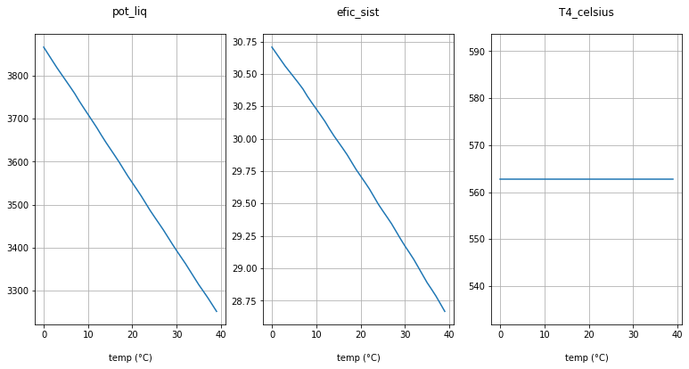

```python
cols_alvo       = ['pot_liq', 'efic_sist', 'T4_celsius']
temp_df         = DataFrame(novos_params, columns=cols_alvo)
temp_df['temp'] = T

fig, axes = plt.subplots(1,3)

for num, col in enumerate(cols_alvo):
    axes[num].plot(temp_df['temp'], temp_df[col])
    axes[num].grid()
    axes[num].set_title(col+'\n')
    axes[num].set_xlabel('\ntemp (°C)')

plt.show()
```

$$$$

Acima notamos um crescimento inversamento proporcional para potência líquida e eficiência do sistema, enquanto a temperatura de saída dos gases quase não varia. $$$$

$$$$

Para análise da variação da potência elétrica vamos variar a temperatura máxima de operação entre $800 °C$ e $1067 °C$. $$$$

```python
sistema_A_otim.temp_comp = 15 # voltando para temperatura ambiente

novos_params = []

# temperatura máxima de ciclo (°C)
T = np.arange(800, 1067, 1)

for temp in T:

    sistema_A_otim.tempMax_ciclo = temp
    sistema_A_otim.simulacao()
    novos_params.append(sistema_A_otim.get_all_params())

tempCiclo_df = DataFrame(novos_params)
```

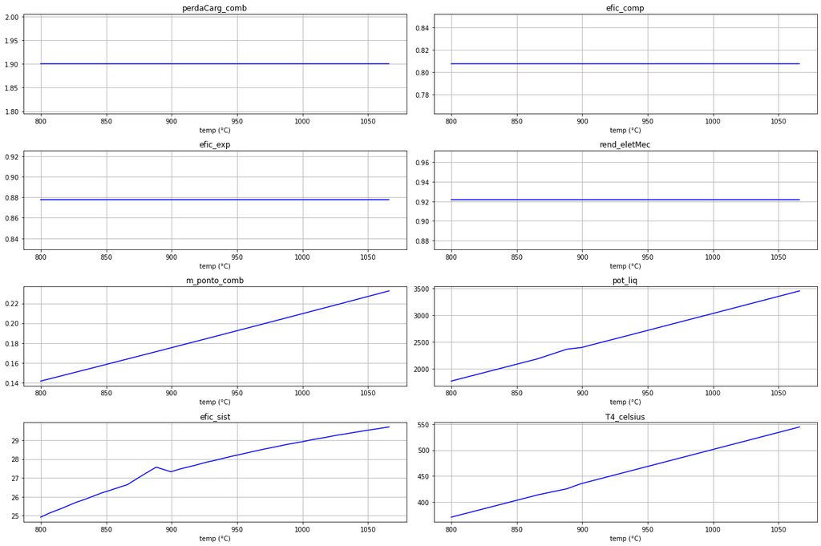

```python
rcParams['figure.figsize'] = 18, 12

cols_alvo = tempCiclo_df.columns.tolist()
cols_alvo.remove('tempMax_ciclo')

fig, axes = plt.subplots(4,2)
axes      = axes.flatten()

for num, col in enumerate(cols_alvo):
    axes[num].plot(tempCiclo_df['tempMax_ciclo'], tempCiclo_df[col], color='blue')
    axes[num].grid()
    axes[num].set_title(col)
    axes[num].set_xlabel('temp (°C)')

fig.tight_layout()
plt.show()
```

$$$$

Enquanto algumas variáveis crescem linearmente outras se apresentam estáticas em relação à mudança de temperatura máxima de ciclo.

Para estime a emissão de $CO_{2}$ associada à operação da $ASE50$ simplificaremos alguns pontos:

- gás natural composto apenas por metano ($CH_{4}$)
- fornecimento ilimitado de comburente ($CH_{4}:CO_{2} \rightarrow 1mol:1mol$)

```python
# retormando o modelo Otimizado
sistema_A_otim.set_params(linha['perdaCarg_comb'],
                          linha['tempMax_ciclo'],
                          linha['efic_comp'],
                          linha['efic_exp'],
                          linha['rend_eletMec'])

sistema_A_otim.simulacao()

mm_ch4 = 16e-3 # Massa Molar CH4 (kg/mol)
mm_co2 = 44e-3 # Massa Molar CH4 (kg/mol)

# kJ/mol = (kJ/kg) * (kg/mol)
pci_comb = sistema_A_otim.pci_gas * mm_ch4

# mol/s  = (kJ/s) / (kJ/mol)
mol_ponto_comb = sistema_A_otim.Q_in / pci_comb

# kg/s (-> kW)
m_ponto_co2 = mol_ponto_comb * mm_co2

# mol/h  = (kJ/s) * (1E-3 * 3600) / (kJ/mol)
mol_ponto_co2_MWh = sistema_A_otim.Q_in * 3.6 / pci_comb

kg_co2_MWh        = mol_ponto_co2_MWh * mm_co2

mostra({'m_ponto_co2':str(round(m_ponto_co2,2)) +' kg/s',
        'kg_co2_MWh': str(round(kg_co2_MWh,2))  +' kg/h'},
        'Emissão de CO2', '')
```

|  | m_ponto_co2 | kg_co2_MWh | Emissão de CO2 |
| --- | --- | --- | --- |
| 0 | 0.65 kg/s | 2.36 kg/h |  |

$$$$

O controle operacional de uma turbina a gás associado ao *de-rating* acontece controlando as pás diretoras móveis na entrada do compressor e a temperatura de entrada da turbina.

Essa temperatura de entrada pode ser contida através do controle da injeção de combustível junto da posição das pás. A configuração das fileiras de pas permitem uma alta temperatura da saída dos gases (até metade da carga).

$$$$

$$$$

# **Parte B**

$$$$

O modelo proposto é representado pela classe abaixo.

$$$$

```python
# O prefixo "a." pode ser ignorado, é apenas uma peculiaridade da linguagem que permite
# todas as funções (da mesma classe) enxergarem a variável com esse prefixo

class TurbinaB():
  ''' Essa classe caracteriza o sistema TURBINA onde o fluído é um Gás ideal'''

  def __init__(a, m_ponto, empuxo_max, empuxo_cruz,comb_dec_espcf, comb_cruz_espcf, T_dec_C, p_iso, T_amb_C, p_amb_kPa, T_max_opr, rp_comp, V_in, PCI, efic_iso_comp, efic_iso_exp, efic_dif_boc, perda_carga, mar):
    ''' Inicializa os parâmetros '''

    a.m_ponto         = m_ponto         # Fluxo de ar no compressor
    a.empuxo_max      = empuxo_max      # Empuxo máximo na decolagem
    a.empuxo_cruz     = empuxo_cruz     # Empuxo em condições de cruzeiro
    a.comb_dec_espcf  = comb_dec_espcf  # Consumo específico de decolagem
    a.comb_cruz_espcf = comb_cruz_espcf # Consumo específico de cruzeiro
    a.T_dec_C         = T_dec_C         # Temperatura de decolagem
    a.p_iso           = p_iso           # Pressão ISO
    a.T_amb_C         = T_amb_C         # Temperatura ambiente em ºC
    a.p_amb_kPa       = p_amb_kPa       # Pressão ambiente em kPa
    a.T_max_opr       = T_max_opr       # Temperatura máxima de operação
    a.rp_comp         = rp_comp         # Relação de pressões na compressão
    a.V_in            = V_in            # V in
    a.PCI             = PCI             # PCI
    a.efic_iso_comp   = efic_iso_comp   # Eficiência do compressor
    a.efic_iso_exp    = efic_iso_exp    # Eficiência do expansor
    a.efic_dif_boc    = efic_dif_boc    # Eficiência do difusor e do bocal
    a.perda_carga     = perda_carga     # Perda de carga
    a.mar             = mar             # Massa de ar

    a.ar = Gas_ideal()    # Fluído

    a.CelsiusToKelvin = 273.15       # °C  -> K
    a.AtmTokPa        = 101.325      # atm -> kPa
    a.R_ar            = 8.314/28.96  # kJ/kg.C
    a.MtoInches       = 39.3701      # m   -> in
    a.Ntolbf          = 0.22481      # N   -> lbf

  def propriedades_aviao(a):
    ''' Calcula as propriedades do avião '''

    # Conversões
    a.T_amb_K = a.T_amb_C + a.CelsiusToKelvin
    a.T_dec_K = a.T_dec_C + a.CelsiusToKelvin
    a.V_iso   = a.T_dec_K*a.R_ar/a.p_iso # PV = RT

    a.prop_cruz = a.ar.get_propTerm(T = a.T_amb_K) # Propriedades de cruzeiro

    # Consumo de combustível
    a.comb_dec  = (a.comb_dec_espcf * a.empuxo_max)/1000   # Consumo de combustível na decolagem
    a.comb_cruz = (a.comb_cruz_espcf * a.empuxo_cruz)/1000 # Consumo de combustível em cruzeiro

    # Dados de cruzeiro
    a.volume_especifico = (a.R_ar * a.T_amb_K) / a.p_amb_kPa # Volume específico
    a.densidade         = 1 / a.volume_especifico            # Densidade
    if a.mar > 0:
      a.m_ar = a.mar
    else:
      a.m_ar = (a.m_ponto * a.V_iso) / a.volume_especifico
    a.fluxo_ar     = a.m_ar * a.volume_especifico  # Fluxo de ar
    a.area_frontal = a.fluxo_ar / a.V_in           # Área frontal
    a.diametro     = (a.area_frontal*4/np.pi)**0.5 # Diâmetro
    a.diametro_pol = a.diametro * a.MtoInches      # Diâmetro em polegadas

    # Interpolações
    a.h1    = a.prop_cruz['h'] + (((a.V_in**2)/2)/1000)         # Entalpia 1
    a.prop1 = a.ar.get_propTerm(h = a.h1)                       # Propridades do estado 1
    a.p1    = (a.prop1['pr'] / a.prop_cruz['pr']) * a.p_amb_kPa # Pressão 1

    a.pr2    = a.prop1['pr'] * a.rp_comp                        # Pressão isentrópica 2
    a.prop2s = a.ar.get_propTerm(pr = a.pr2)                    # Propriedades isentrópicas do estado 2
    a.p2     = a.p1 * a.rp_comp                                 # Pressão 2

    a.h2    = a.h1 + (a.prop2s['h'] - a.h1) / a.efic_iso_comp   # Entalpia 2
    a.prop2 = a.ar.get_propTerm(pr = a.pr2)                     # Propriedades do estado 2

    a.p3    = a.p2 * (1-a.perda_carga)                          # Pressão 3
    a.prop3 = a.ar.get_propTerm(T = a.T_max_opr)                # Propriedades do estado 3

  def compressor_exaustor(a):
    ''' Calcula os parâmetros do compressor e do exaustor '''

    # Resultados Compressor e Exaustor
    a.m_comb = (a.m_ar * (a.prop3['h'] - a.h2)) / (a.PCI - a.prop3['h']) # Consumo de combustível
    a.m_comb_hora = a.m_comb * 3600                                      # Consumo de combustível por hora
    a.W_comp = a.m_ar * (a.h2 - a.h1)                                    # Potência do compressor
    a.W_comp_kg = a.W_comp / a.m_ar                                      # Potência do compressor por kg
    a.W_exp = a.W_comp                                                   # Potência do expansor
    a.W_exp_kg = a.W_exp / (a.m_ar + a.m_comb)                           # Potência do expansor por kg

  def exaustao(a):
    ''' Calcula os parâmetros no estado da exaustão '''

    a.h4s    = a.prop3['h'] - (a.W_exp / ((a.m_ar + a.m_comb) * a.efic_iso_exp)) # Entalpia isentrópica 4
    a.prop4s = a.ar.get_propTerm(h = a.h4s)                                      # Propriedades isentrópicas do estado 4
    a.p4     = a.p3/(a.prop3['pr']/a.prop4s['pr'])                               # Pressão 4

    a.h4    = a.prop3['h'] - a.efic_iso_exp * (a.prop3['h'] - a.h4s)             # Entalpia 4
    a.prop4 = a.ar.get_propTerm(h = a.h4)                                        # Propriedades do estado 4

    a.p5    = a.p_amb_kPa                                                        # Pressão 5
    a.pr5   = a.prop4['pr'] / (a.p4/a.p5)                                        # Pressão isentrópica 5
    a.prop5 = a.ar.get_propTerm(pr = a.pr5)                                      # Propriedades do estado 5

  def calculos_finais(a):
    ''' Cálculos finais '''

    a.V_exaust = (2*(a.h4 - a.prop5['h'])*1000) ** 0.5                # Velocidade no exaustor
    a.F_empuxo = (a.m_ar + a.m_comb) * a.V_exaust - (a.m_ar * a.V_in) # Empuxo
    a.F_empuxo_lbf = a.F_empuxo * a.Ntolbf                            # Empuxo em lbf
    a.TSFC = a.m_comb_hora / (a.F_empuxo/1000)
    a.TSFC_lb = a.TSFC / 101.973
    a.desvio_empuxo_especifico = a.F_empuxo / a.m_ar                  # Desvio específico do empuxo
    a.empuxo_especifico = (a.m_comb*1000) / (a.F_empuxo/1000)         # Empuxo específico
    a.desvio_comb = (a.m_comb / a.comb_cruz)                          # Desvio do consumo de combustível
    a.desvspec_comb = (a.empuxo_especifico/a.comb_cruz_espcf) - 1     # Desvio do consumo específico de combustível
    a.desvio_empuxo = (a.F_empuxo / a.empuxo_cruz) - 1                # Desvio do empuxo

  def get_eficiencia_sistema(a):
    ''' Calcula eficiência propulsiva do sistema '''

    a.efic_sist = (1/(2+(a.V_in/a.V_exaust))) * 100

    return a.efic_sist

  def set_altitude(a, T_amb_C, p_amb_kPa):
    ''' Seta os parâmetros de temperatura e pressão
        1. T_amb_C:   Temperatura ambiente em ºC
        2. p_amb_kPa: Pressão ambiente em kPa
    '''

    a.T_amb_C   = T_amb_C
    a.p_amb_kPa = p_amb_kPa

  def set_params(a, perda_carga, T_max_opr, efic_iso_comp, efic_iso_exp, efic_dif_boc):
    ''' Seta os parâmetros de entrada da simulação
        1. perda_carga: Perda de carga na câmara de combustão
        2. T_max_opr: Temperatura máxima operacional da turbina em cruzeiro
        3. efic_iso_comp: Eficiência isoentrópica do compressor
        4. efic_iso_exp: Eficiência isoentrópica do expansor
        5. efic_dif_boc: Eficiências isoentrópicas no difusor e no bocal
    '''
    a.perda_carga   = perda_carga
    a.T_max_opr     = T_max_opr
    a.efic_iso_comp = efic_iso_comp
    a.efic_iso_exp  = efic_iso_exp
    a.efic_dif_boc  = efic_dif_boc

  def get_params(a):
    ''' Retorna os parâmetros de saída da simulação
        1. F_empuxo: Empuxo em condições de cruzeiro
        2. m_comb: Consumo de combustível
        3. empuxo_especifico: Empuxo específico em cruzeiro
    '''
    return [a.F_empuxo,a.m_comb*1000,a.empuxo_especifico]

  def get_desvios(a):
    ''' Retorna os desvios do parâmetro de saída da simulação com relação aos parâmetros operacionais do fabricante
        1. desvio_empuxo: Empuxo em condições de cruzeiro
        2. desvio_comb: Consumo de combustível
        3. desvspec_comb: Empuxo específico em cruzeiro
    '''
    return [a.desvio_empuxo*100,a.desvio_comb*100,a.desvspec_comb*100]

  def get_params_desvios(a):
    ''' Retorna os parâmetros de saída da simulação
        1. F_empuxo: Empuxo em condições de cruzeiro
        2. m_comb: Consumo de combustível
        3. empuxo_especifico: Empuxo específico em cruzeiro
        4. desvio_empuxo: Desvio empuxo em condições de cruzeiro
        5. desvio_comb: Desvio consumo de combustível
        6. desvspec_comb: Desvio empuxo específico em cruzeiro
    '''
    return [a.F_empuxo,a.m_comb*1000,a.empuxo_especifico,a.desvio_empuxo*100,a.desvio_comb*100,a.desvspec_comb*100]

  def simulacao(a):
    ''' Faz a simulação dos processos '''
    a.propriedades_aviao()
    a.compressor_exaustor()
    a.exaustao()
    a.calculos_finais()
```

$$$$

Para fazer a validação do modelo, ele é executado utilizando os parâmetros arbitrados no enunciado.

$$$$

```python
# Parâmetros de entrada
perda_carga = 2.5/100
T_max_opr = 1067
efic_iso_comp = .87
efic_iso_exp = .87
efic_dif_boc = 1

# Propriedades do modelo
sistema_B = TurbinaB(m_ponto = 81.65,
                     empuxo_max = 53500,
                     empuxo_cruz = 15800,
                     comb_dec_espcf = 22.2,
                     comb_cruz_espcf = 25.7,
                     T_dec_C = 15,
                     p_iso = 101.325,
                     T_amb_C = -43.15,
                     p_amb_kPa = 31.2,
                     T_max_opr = 1067,
                     rp_comp = 12.5,
                     V_in = 260,
                     PCI =42800,
                     efic_iso_comp = .87,
                     efic_iso_exp = .87,
                     efic_dif_boc = 1,
                     perda_carga = 2.5/100,
                     mar = -1)

# Executa simulação
sistema_B.simulacao()

parametros = sistema_B.get_params()
desvios    = sistema_B.get_desvios()

df_B = DataFrame({'Parâmetro' : ['Empuxo em condições de cruzeiro', 'Consumo de combustível', 'Empuxo específico em cruzeiro'],
                  'Resultado' : [parametros[0].round(2),parametros[1].round(2),parametros[2].round(2)],
                  'Unidade'   : ['N','g/s','(g/s)/kN'],
                  'Desvio'    : [desvios[0].round(2),desvios[1].round(2),desvios[2].round(2)],
                  ''          : ['%','%','%']})
df_B.head()
```

|  | Parâmetro | Resultado | Unidade | Desvio |  |
| --- | --- | --- | --- | --- | --- |
| 0 | Empuxo em condições de cruzeiro | 15988.82 | N | 1.20 | % |
| 1 | Consumo de combustível | 406.11 | g/s | 0.10 | % |
| 2 | Empuxo específico em cruzeiro | 25.40 | (g/s)/kN | -1.17 | % |

$$$$

Como podemos ver, os resultados são bem próximos dos resultados na simulação do enunciado.

$$$$

Para que seja possível otimizar o sistema com os parâmetros arbitrados no enunciado, é gerado um vetor de 6 elementos contidos em um espaço entre $\pm$ $10$% com relação ao parâmetro arbitrado, para que se simule todas as combinações entre esses parâmetros novos.

$$$$

Os parâmetros ajustados são:

- Perda de carga na câmara de combustão;
- Temperatura máxima operacional da turbina em cruzeiro;
- Eficiência isoentrópica do compressor;
- Eficiência isoentrópica do expansor;
- Eficiências isoentrópicas no difusor e no bocal.

$$$$

```python
# Gerando novos parâmetros para otimização
params = {key:value for key, value in zip(['perda_carga','T_max_opr','efic_iso_comp','efic_iso_exp','efic_dif_boc'],
                                          [perda_carga,T_max_opr,efic_iso_comp,efic_iso_exp,efic_dif_boc])}

# Vetor de 10% dos parâmetros de entrada
var_params = {k:get_vet_var_10(v,k, num=6) for k,v in params.items()}

combinacoes = np.array(np.meshgrid(var_params['perda_carga'],
                                   var_params['T_max_opr'],
                                   var_params['efic_iso_comp'],
                                   var_params['efic_iso_exp'],
                                   var_params['efic_dif_boc'])).T.reshape(-1,5)

df_comb = DataFrame(combinacoes, columns=params.keys())

df_comb.head()
```

|  | perda_carga | T_max_opr | efic_iso_comp | efic_iso_exp | efic_dif_boc |
| --- | --- | --- | --- | --- | --- |
| 0 | 0.0225 | 960.30 | 0.783 | 0.783 | 0.9 |
| 1 | 0.0225 | 1002.98 | 0.783 | 0.783 | 0.9 |
| 2 | 0.0225 | 1045.66 | 0.783 | 0.783 | 0.9 |
| 3 | 0.0225 | 1088.34 | 0.783 | 0.783 | 0.9 |
| 4 | 0.0225 | 1131.02 | 0.783 | 0.783 | 0.9 |

$$$$

Após os parâmetros de entrada serem devidamente gerados e organizados, obtém-se os resultados das simulações de todas as combinações possíveis dentro desses parâmetros gerados.

$$$$

```python
# Fazendo cópia do sistema
sistema_B_otim = deepcopy(sistema_B)

novos_params   = []

# Simulação para cada um dos novos parâmetros
for i in range(df_comb.shape[0]):

    linha = df_comb.iloc[i,:]

    sistema_B_otim.set_params(linha['perda_carga'],
                              linha['T_max_opr'],
                              linha['efic_iso_comp'],
                              linha['efic_iso_exp'],
                              linha['efic_dif_boc'])

    sistema_B_otim.simulacao()

    novos_params.append(sistema_B_otim.get_params_desvios())
```

```python
novos_params_df = DataFrame(novos_params, columns=['F_empuxo', 'm_comb', 'empuxo_especifico','desvio_empuxo','desvio_comb','desvspec_comb'])
novos_params_df.head()
```

|  | F_empuxo | m_comb | empuxo_especifico | desvio_empuxo | desvio_comb | desvspec_comb |
| --- | --- | --- | --- | --- | --- | --- |
| 0 | 8427.785303 | 286.023483 | 33.938155 | -46.659587 | 0.070439 | 32.055077 |
| 1 | 10204.220510 | 322.987140 | 31.652309 | -35.416326 | 0.079542 | 23.160735 |
| 2 | 11821.424363 | 360.314211 | 30.479763 | -25.180858 | 0.088734 | 18.598299 |
| 3 | 13236.910140 | 397.941110 | 30.062991 | -16.222088 | 0.098001 | 16.976618 |
| 4 | 14591.098646 | 435.935243 | 29.876794 | -7.651274 | 0.107357 | 16.252115 |

```python
# Concatenando o retorno das simulações com suas respectivas entradas
df_B = concat([df_comb.reset_index(drop=True), novos_params_df], axis=1)
df_B.head()
```

|  | perda_carga | T_max_opr | efic_iso_comp | efic_iso_exp | efic_dif_boc | F_empuxo | m_comb | empuxo_especifico | desvio_empuxo | desvio_comb | desvspec_comb |
| --- | --- | --- | --- | --- | --- | --- | --- | --- | --- | --- | --- |
| 0 | 0.0225 | 960.30 | 0.783 | 0.783 | 0.9 | 8427.785303 | 286.023483 | 33.938155 | -46.659587 | 0.070439 | 32.055077 |
| 1 | 0.0225 | 1002.98 | 0.783 | 0.783 | 0.9 | 10204.220510 | 322.987140 | 31.652309 | -35.416326 | 0.079542 | 23.160735 |
| 2 | 0.0225 | 1045.66 | 0.783 | 0.783 | 0.9 | 11821.424363 | 360.314211 | 30.479763 | -25.180858 | 0.088734 | 18.598299 |
| 3 | 0.0225 | 1088.34 | 0.783 | 0.783 | 0.9 | 13236.910140 | 397.941110 | 30.062991 | -16.222088 | 0.098001 | 16.976618 |
| 4 | 0.0225 | 1131.02 | 0.783 | 0.783 | 0.9 | 14591.098646 | 435.935243 | 29.876794 | -7.651274 | 0.107357 | 16.252115 |

$$$$

Para cada um dos resultados das simulações é calculado um erro total, que consiste na soma dos desvios de todos os parâmetros de saída com relação aos parâmetros operacionais do fabricante.

$$$$

Assim, ordenando os resultados das simulações pelo menor erro, obtemos o modelo que obteve o menor erro. Uma comparação do modelo otimizado com o modelo arbitrado pode ser vista na tabela abaixo. $$$$

```python
# Erro total (módulos dos erros)
df_B['erro_total'] = np.abs(df_B['desvio_empuxo']) + np.abs(df_B['desvio_comb']) + np.abs(df_B['desvspec_comb'])

# Estruturando em tabela
aux                  = df_B.sort_values('erro_total').iloc[:1,:].T.round(2)
aux['Modelo antigo'] = [perda_carga,T_max_opr,efic_iso_comp,efic_iso_exp,efic_dif_boc]+sistema_B.get_params_desvios()+[abs(desvios[0])+abs(desvios[1])+abs(desvios[2])]
aux['Unidade']       = ['%', '°C', '%', '%', '%', 'N', 'g/s', '(g/s)/kN', '%', '%', '%', '%']
aux.columns          = ['Parâmetros novos', 'Parâmetros antigos','Unidades']

aux.round(2)
```

|  | Parâmetros novos | Parâmetros antigos | Unidades |
| --- | --- | --- | --- |
| perda_carga | 0.02 | 0.02 | % |
| T_max_opr | 1088.34 | 1067.00 | °C |
| efic_iso_comp | 0.82 | 0.87 | % |
| efic_iso_exp | 0.89 | 0.87 | % |
| efic_dif_boc | 1.00 | 1.00 | % |
| F_empuxo | 15829.76 | 15988.82 | N |
| m_comb | 409.45 | 406.11 | g/s |
| empuxo_especifico | 25.87 | 25.40 | (g/s)/kN |
| desvio_empuxo | 0.19 | 1.20 | % |
| desvio_comb | 0.10 | 0.10 | % |
| desvspec_comb | 0.64 | -1.17 | % |
| erro_total | 0.93 | 2.46 | % |

$$$$

Como a tabela nos mostra, o método de otimização se mostrou bem eficaz, reduzindo o erro total em comparação ao modelo arbitrado de $2,46$ % para 0,$93$ %, o que nos fornece uma redução de mais de $164$ % no erro obtido. O desvio mais significativo também mostrou ser na força do empuxo, que obteve uma melhora de perfomance de mais de $500$ %.

$$$$

Para analisarmos a sensibilidade de cada parâmetro de entrada, podemos utilizar a propriedade da correlação dos parâmetros de entrada com os parâmetros de saída. Desse modo, obtemos a tabela de correlação abaixo:

$$$$

```python
# Correlações
avalia_sensibilidades_corr('B')
```

|  | perda_carga | T_max_opr | efic_iso_comp | efic_iso_exp |
| --- | --- | --- | --- | --- |
| F_empuxo | -1.0 | 0.9999 | 0.9993 | 0.9990 |
| m_comb | 0.0 | 1.0000 | 0.9997 | -0.0000 |
| empuxo_especifico | 1.0 | 0.9995 | -0.9968 | -0.9981 |

$$$$

Analisando os resultados, percebe-se uma correlação muito alta dos parâmetros de entrada com os resultados da simulação, com exceção da perda de carga e da eficiência do expandor, que não têm efeito nenhum na saída do consumo de combustível.

$$$$

Agora que os parâmetros do modelo otimizado foram obtidos, é necessário recuperá-los, como segue.

$$$$

```python
# Recuperando os parâmetros do sistema otimizado
linha = df_B.sort_values('erro_total').iloc[0,:]

novos_params = []

sistema_B_otim.set_params(linha['perda_carga'],
                          linha['T_max_opr'],
                          linha['efic_iso_comp'],
                          linha['efic_iso_exp'],
                          linha['efic_dif_boc'])

# Simulação do sistema otimizado
sistema_B_otim.simulacao()
parametros_otim = sistema_B_otim.get_params()
desvios_otim    = sistema_B_otim.get_desvios()
```

$$$$

Agora, utilizando o modelo otimizado como base, podemos analisar seu desempenho em diferentes condições e altitudes. Por exemplo, para o sistema com altitude de $2000$ m abaixo, ou seja, em cruzeiro a $7000$ m de altitude, obtemos os parâmetros de temperatura e pressão ambiente de $-30,5$ ºC e $41,06$ kPa. Realizando a simulação para o sistema sob essas condições, obtemos os resultados mostrados na tabela abaixo.

$$$$

```python
# Sistema a 7000 metros de altidude
sistema_B_7000 = deepcopy(sistema_B_otim)

sistema_B_7000.set_altitude(-30.5000, 41.0607)

sistema_B_7000.simulacao()

params_7000 = sistema_B_7000.get_params()
desvios_7000 = sistema_B_7000.get_desvios()

# Comparação das perfomances nas duas altitudes
df_7000 = DataFrame({'Parâmetro' : ['Consumo de combustível', 'Desvio de consumo de combustível'],
                     '9000 m'    : [parametros_otim[1].round(4), desvios_otim[1].round(4)],
                     '7000 m'    : [params_7000[1].round(4), desvios_7000[1].round(4)],
                     'Unidade'   : ['g/s', '%']})
df_7000.head()
```

|  | Parâmetro | 9000 m | 7000 m | Unidade |
| --- | --- | --- | --- | --- |
| 0 | Consumo de combustível | 409.4455 | 483.5657 | g/s |
| 1 | Desvio de consumo de combustível | 0.1008 | 0.1191 | % |

$$$$

Como esperado, em uma altitude mais baixa houve um aumento no consumo de combustível de $18,1$%. Isso também nos mostra que, a altitudes mais baixas, a turbina tem um desempenho pior do que a altitude em que o modelo otimizado foi projetado, já que para o mesmo funcionamento é necessário uma quantidade maior de combustível, que é proporcional a potência requerida pela turbina.

$$$$

$$$$

```python
# Simulação para as decolagens em nível do mar e na Cidade do México
sistema_B_ISO    = deepcopy(sistema_B_otim)
sistema_B_Mexico = deepcopy(sistema_B_otim)

sistema_B_ISO.set_altitude(15, 101.325)
sistema_B_Mexico.set_altitude(28, 77.0585)

sistema_B_ISO.simulacao()
sistema_B_Mexico.simulacao()

params_ISO     = sistema_B_ISO.get_params()
desvios_ISO    = sistema_B_ISO.get_desvios()
params_Mexico  = sistema_B_Mexico.get_params()
desvios_Mexico = sistema_B_Mexico.get_desvios()
```

```python
mostra_mex_ISO()
```

|  | Parâmetro | Cruzeiro | ISO | Cidade do México | Unidade |
| --- | --- | --- | --- | --- | --- |
| 0 | Empuxo em condições de cruzeiro | 15829.76 | 28903.80 | 18793.98 | N |
| 1 | Consumo de combustível | 409.45 | 802.60 | 541.90 | g/s |
| 2 | Empuxo específico em cruzeiro | 25.87 | 27.77 | 28.83 | (g/s)/kN |
| 3 | Desvio empuxo em condições de cruzeiro | 0.19 | 82.94 | 18.95 | % |
| 4 | Desvio de consumo de combustível | 0.10 | 0.20 | 0.13 | % |
| 5 | Desvio empuxo específico em cruzeiro | 0.64 | 8.05 | 12.19 | % |

$$$$

Para as simulações realizadas, a que se mostrou mais custosa foi sob as condições ISO, que obteve um aumento muito grande no consumo de combustível e na força do empuxo de quase $100$ %. A decolagem na Cidade do México também mostrou um desempenho mais custoso, com um aumento no consumo de combustível de mais de $30$ %.

$$$$

Sendo $v_e$ a velocidade de entrada e $v_s$ a velocidade de saída do fluído na turbina. Os resultados foram mostrados abaixo.

$$$$

```python
# Eficiência propulsiva dos modelos simulados
eficiencia_otim = sistema_B_otim.get_eficiencia_sistema()
eficiencia_mex  = sistema_B_Mexico.get_eficiencia_sistema()
eficiencia_ISO  = sistema_B_ISO.get_eficiencia_sistema()

d_efic = DataFrame({'Cruzeiro': [eficiencia_otim.round(1)],
                    'ISO'     : [eficiencia_ISO.round(1)],
                    'México'  : [eficiencia_mex.round(1)],
                    'Unidade' : ['%']})
d_efic.head()
```

|  | Cruzeiro | ISO | México | Unidade |
| --- | --- | --- | --- | --- |
| 0 | 42.6 | 41.2 | 40.7 | % |

$$$$

A melhor performance obtida foi sob as condições de cruzeiro, como esperado. Curiosamente, os dados apesar dos piores resultados terem sido obtidos sob as condições ISO de temperatura e pressão, a eficiência propulsiva se mostrou melhor do que a eficiência propulsiva na Cidade do México.

$$$$

Como mostra a simulação, para se fazer um controle do empuxo pode-se monitorar um parâmetro como a velocidade de exaustão ou a massa de combustível consumida, já que ambos estão diretamente associados a força do empuxo. Portanto, para que o controle funcione corretamente, o sistema de controle deve atuar sob um parâmetro de entrada que esteja associado ao parâmetro escolhido para monitoração, como a massa de combustível injetada na câmara de combustão.

$$$$